# DISTRIBUTION OF RIDERS AND RIDES IN THE FORD BIKE SHARE DATA

## by (David Masila)

## Investigation Overview

In this investigation i wanted to know the demographic characteristics of participants in the ford bike share program. I also wanted to know what factors influencing participation in the program, be it age, gender, time and and how they affected the program and riders in general.

## Dataset Overview

This data set includes information about individual rides made in a bike-sharing system covering the greater San Francisco Bay area

# Number of rides by hour of day.

Most of the rides in the bike share program are taken at 5pm and 8 am. These are the peak hours when traffic is highest

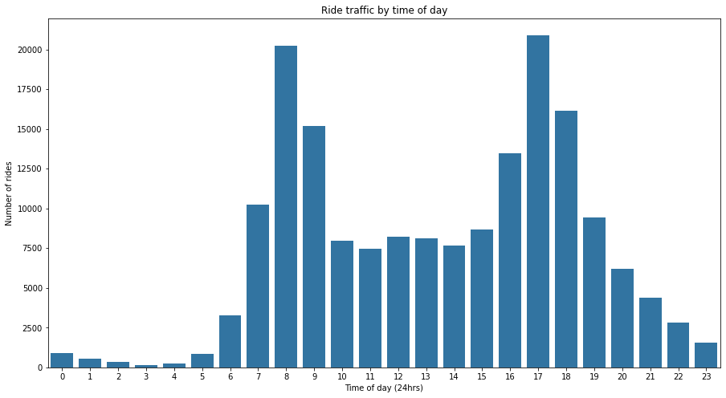

## Number of Bicycle rides per day of Week

Thursday has the highest number of rides compared to any other day of the week. Overally, weekdays seem to have the most rides while weekends have the least ride numbers

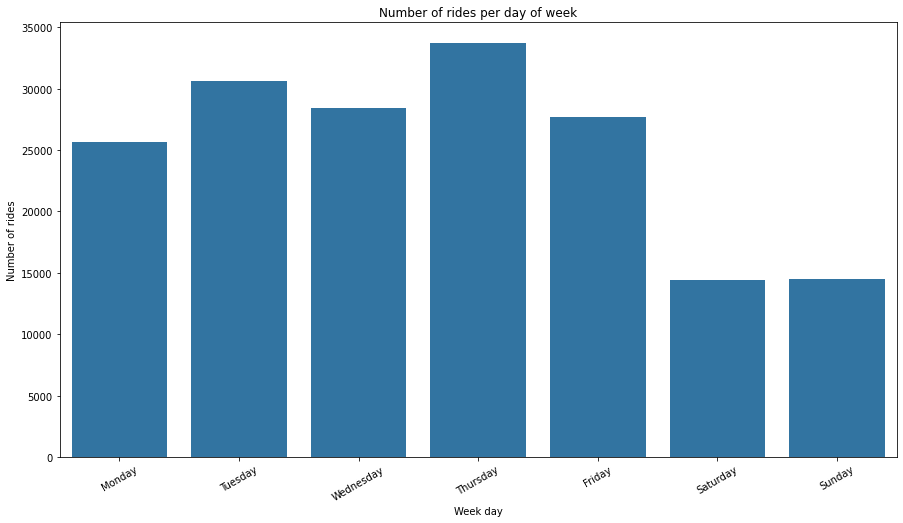

## Distribution of rider numbers by gender

The number of male riders in the program was by far the largest compared to female and others gender types.

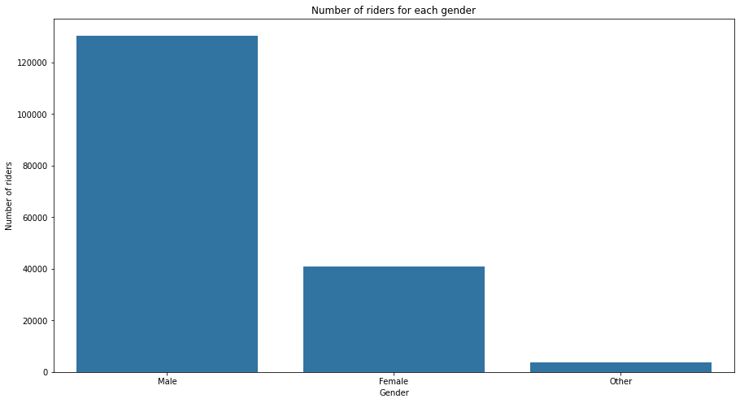

## Rider numbers per age group and day of the week

People in their thirties are very active in the bike share program. Their daily riders are by far more compared to the rest of the age groups

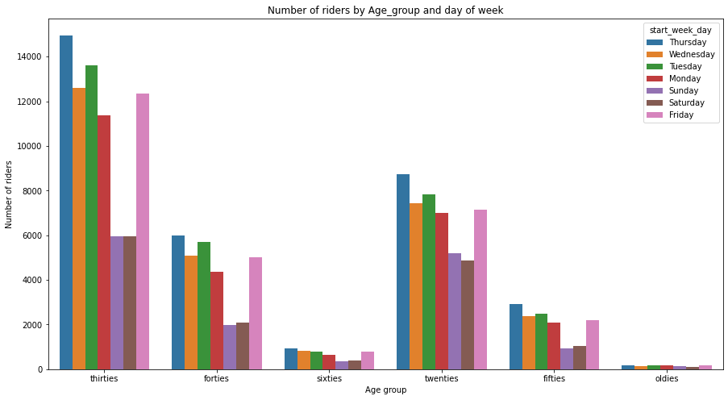

## Duration of rides by Age and user type

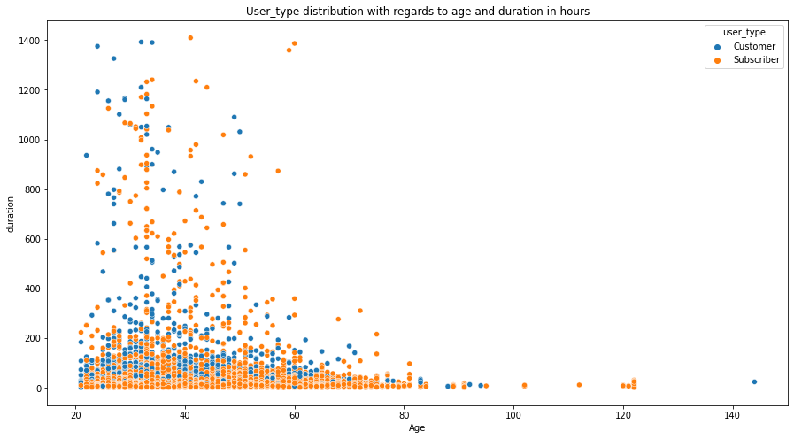